# Linear Regression

Linear regression is used to model the relationship between a numeric outcome variable and one or more features by fitting a linear equation to the data. The model estimates coefficients that minimize the sum of squared residuals. Linear Regression is one of the oldest predictive modeling techniques.

### Use Cases

- Predicting housing prices from square footage and location
- Estimating insurance premiums from age and health indicators
- Forecasting company revenue based on marketing spend
- Estimating blood pressure based on age and BMI
- Forecasting electricity demand from temperature and time of day

### Strengths

- Well-understood and extensively used
- Fast and computationally efficient
- Easy to interpret and communicate

### Weaknesses

- Assumes a linear relationship between features and outcome
- Sensitive to multicollinearity, outliers, and missing data
- Cannot capture complex non-linear interactions unless transformed
- Makes a number of assumptions such as constant variance and normally distributed errors

## Overview

This note will demonstrate the use of Linear Regression to estimate earnings based on characteristics of individuals. The note will examine simple regression with a numeric feature, simple regression with a categorical feature, multiple regression with an interaction, and multiple regression with a combination of numerical and categorical features. All models will be estimated using functions from StatsModels as it provides statistical details. For an implementation using Scikit-Learn, look at the other note on Linear Regression.

## Data Description

Earning data is derived from a survey of individuals on a multitude of characteristics including demographics, physical characteristics, health, well-being and earning. (Original Data Source: Regression and Other stories, by Andrew Gelman, Jennifer Hill, and Avi Vekhtari). We are interested in examining the factors that influence annual earning (`earn`) and predicting an individuals annual earning.

Data consists of characteristics of a set of employees and their annual earning. Variables included are:

- earn: Annual earning in dollars
- age: Age in years
- gender: male, female
- height: Height in inches
- weight: Weight in pounds
- ethnicity: White, African American, Hispanic, Asian
- education: Years of education
- walk: Frequency of taking a walk (in a week)
- exercise: Frequency of strenuous exercise (in a week)
- smokenow: Smoke seven or more cigarettes a week (1 = Yes, 2 = No)
- tense: Days felt tense or anxious

## Read Data

```python
import pandas as pd
data = pd.read_csv('earning.csv')
```

## Data Partition

Evaluating a model using data to estimate it risks overfitting the model to the data used to build it. For this reason, it is best to evaluate the model using a different dataset. Since getting a fresh dataset for evaluating a model may be costly, time consuming and in some cases impossible, it is common to split the data into a train and test sample, estimating the model using the train and evaluating it using the test.

```python
train = data.sample(frac = 0.7,random_state=617)
test = data.drop(labels = train.index)
```

## Explore Data

```python
train.info()
```

```
<class 'pandas.core.frame.DataFrame'>
Index: 1250 entries, 384 to 556
Data columns (total 11 columns):
 #   Column     Non-Null Count  Dtype
---  ------     --------------  -----
 0   earn       1250 non-null   int64
 1   age        1250 non-null   int64
 2   gender     1250 non-null   object
 3   height     1250 non-null   int64
 4   weight     1250 non-null   int64
 5   ethnicity  1250 non-null   object
 6   education  1250 non-null   int64
 7   walk       1250 non-null   int64
 8   exercise   1250 non-null   int64
 9   smokenow   1250 non-null   int64
 10  tense      1250 non-null   int64
dtypes: int64(9), object(2)
memory usage: 117.2+ KB
```

```python
train.head()
```

|  | earn | age | gender | height | weight | ethnicity | education | walk | exercise | smokenow | tense |
| --- | --- | --- | --- | --- | --- | --- | --- | --- | --- | --- | --- |
| 384 | 7437 | 34 | male | 75 | 180 | African American | 11 | 8 | 7 | 1 | 0 |
| 621 | 144460 | 48 | male | 70 | 185 | White | 11 | 1 | 1 | 2 | 0 |
| 1331 | 0 | 75 | female | 65 | 153 | White | 9 | 1 | 1 | 2 | 0 |
| 1264 | 34950 | 62 | female | 59 | 180 | White | 12 | 1 | 1 | 2 | 0 |
| 268 | 53590 | 47 | female | 67 | 185 | White | 12 | 3 | 1 | 1 | 2 |

```python
train.describe(include = 'all')
```

|  | earn | age | gender | height | weight | ethnicity | education | walk | exercise | smokenow | tense |
| --- | --- | --- | --- | --- | --- | --- | --- | --- | --- | --- | --- |
| count | 1250.000000 | 1250.00000 | 1250 | 1250.000000 | 1250.000000 | 1250 | 1250.00000 | 1250.000000 | 1250.000000 | 1250.000000 | 1250.000000 |
| unique | NaN | NaN | 2 | NaN | NaN | 4 | NaN | NaN | NaN | NaN | NaN |
| top | NaN | NaN | female | NaN | NaN | White | NaN | NaN | NaN | NaN | NaN |
| freq | NaN | NaN | 779 | NaN | NaN | 1031 | NaN | NaN | NaN | NaN | NaN |
| mean | 49135.323200 | 43.65760 | NaN | 66.629600 | 156.480800 | NaN | 13.20320 | 5.286400 | 3.020000 | 1.749600 | 1.352800 |
| std | 54262.228175 | 17.44403 | NaN | 3.847733 | 34.653842 | NaN | 2.58814 | 2.604343 | 2.305787 | 0.433417 | 2.097964 |
| min | 0.000000 | 18.00000 | NaN | 58.000000 | 80.000000 | NaN | 2.00000 | 1.000000 | 1.000000 | 1.000000 | 0.000000 |
| 25% | 14620.750000 | 30.00000 | NaN | 64.000000 | 130.000000 | NaN | 12.00000 | 3.000000 | 1.000000 | 1.250000 | 0.000000 |
| 50% | 34950.000000 | 40.00000 | NaN | 66.000000 | 150.000000 | NaN | 12.00000 | 6.000000 | 2.000000 | 2.000000 | 0.000000 |
| 75% | 62910.000000 | 57.00000 | NaN | 70.000000 | 180.000000 | NaN | 15.00000 | 8.000000 | 5.000000 | 2.000000 | 2.000000 |
| max | 932000.000000 | 91.00000 | NaN | 82.000000 | 342.000000 | NaN | 18.00000 | 8.000000 | 7.000000 | 2.000000 | 7.000000 |

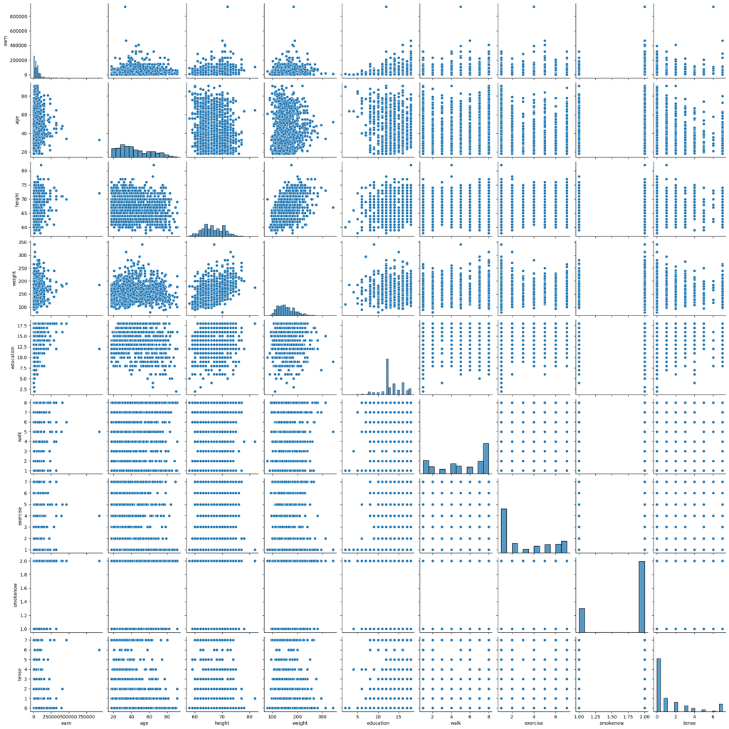

```python
import matplotlib.pyplot as plt
import seaborn as sns
sns.pairplot(train)
plt.show()
```

## Simple Regression: age

As people get older, they gain experience and get better at doing their job. Therefore, it is reasonable to expect age to be positively related to earn. We can visualize this using a scatterplot. Is there a discernible trend?

```python
import matplotlib.pyplot as plt
import seaborn as sns
```

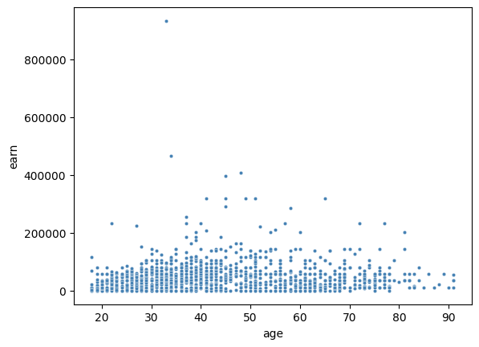

```python
sns.scatterplot(data = train,
                x = 'age',
                y = 'earn',
                color='steelblue',
                s=10)
plt.show()
```

### Correlation

Correlation is a measure of linear association between two continuous variables. We can examine the strength of association between these two variables using pearson product-moment correlation.

```python
train.loc[:,['age','earn']].corr()
```

|  | age | earn |
| --- | --- | --- |
| age | 1.000000 | 0.060472 |
| earn | 0.060472 | 1.000000 |

`.corr()` in pandas is a convenient method for extracting pearson correlations but it does not provide p-values for the coefficients, so will turn to the scipy library.

```python
from scipy.stats import pearsonr
pearsonr(train['age'],train['earn'])
```

```
PearsonRResult(statistic=np.float64(0.060471608039428144), pvalue=np.float64(0.03253201748393041))
```

Correlation results indicate a significant positive relationship between age and earn. However, the correlation coefficient does not specify direction. Common sense suggests age would influence earn and not the other way. So, next we specify a directional relationship using a simple regression.

### Fit Model

Two of the popular Python libraries for implementing linear regression are Scikit-Learn and StatsModels. Scikit-Learn which has a strong machine learning orientation does not provide statistical details that are critical in understanding Linear Regression. For this reason, we will introduce the topic using StatsModels.

```python
from statsmodels.formula.api import ols
```

```python
reg = ols('earn~age', data = train)
model1 = reg.fit()
```

```python
model1.params
```

```
Intercept    40923.073187
age            188.105851
dtype: float64
```

```python
print('Estimated Regression Equation:\n', 'earn = ', model1.params.loc['Intercept'], ' + ', model1.params.loc['age'],'*age')
```

```
Estimated Regression Equation:
 earn =  40923.07318713078  +  188.10585128063107 *age
```

### Predict

```python
print(40895.96136415939 + 168.29888213808906 * 24)
```

```
44935.134535473524
```

Of course, it is not practical to do this for each value to be predicted. So, we rely on the .predict() method.

```python
model1.predict()[0]
```

```
np.float64(47318.67213067224)
```

Let us examine the predictions of the first ten respondents

```python
pd.DataFrame({'age': train.age,
              'predictions': model1.predict(),
              'earn': train.earn}).head(10)
```

|  | age | predictions | earn |
| --- | --- | --- | --- |
| 384 | 34 | 47318.672131 | 7437 |
| 621 | 48 | 49952.154049 | 144460 |
| 1331 | 75 | 55031.012033 | 0 |
| 1264 | 62 | 52585.635967 | 34950 |
| 268 | 47 | 49764.048197 | 53590 |
| 200 | 44 | 49199.730643 | 74560 |
| 435 | 35 | 47506.777982 | 104850 |
| 343 | 61 | 52397.530115 | 8155 |
| 1720 | 19 | 44497.084361 | 58250 |
| 1388 | 34 | 47318.672131 | 111840 |

The quality of predictions can be evaluated by comparing the true value of earn to predictions.

- R2: Popular statistical index
- SSE: Sum of squared errors
- RMSE: Generates an error estimate in the units of the data

##### RMSE

```python
import numpy as np
pred = model1.predict()
rmse1 = np.sqrt(np.mean(np.square(pred - train.earn)))
rmse1
```

```
np.float64(54141.2543281431)
```

##### SSE

```python
sse1 = np.sum(np.square(pred - train.earn))
sse1
```

```
np.float64(3664094275280.8423)
```

##### R-Squared

```python
r_squared1 = model1.rsquared
r_squared1
```

```
np.float64(0.0036568153788744118)
```

### Inference

Regression models are useful not just for prediction but also for explanation. Regression model summary contains information on statistical significance of the overall model and regression coefficients. A p-value of less than alpha indicates the coefficient is different from 0. Unless otherwise stated, we will use an alpha of 0.05.

The F-statistic of 4.580 has a p-value of 0.0325 which is less than 0.05. This indicates the overall model is statistically significant. Since age is the only predictor, not surprisingly, the coefficient of age is also significantly different from 0 (p = 0.033 < 0.05).

```python
print(model1.summary())
```

```
                            OLS Regression Results
==============================================================================
Dep. Variable:                   earn   R-squared:                       0.004
Model:                            OLS   Adj. R-squared:                  0.003
Method:                 Least Squares   F-statistic:                     4.580
Date:                Thu, 25 Sep 2025   Prob (F-statistic):             0.0325
Time:                        18:46:17   Log-Likelihood:                -15398.
No. Observations:                1250   AIC:                         3.080e+04
Df Residuals:                    1248   BIC:                         3.081e+04
Df Model:                           1
Covariance Type:            nonrobust
==============================================================================
                 coef    std err          t      P>|t|      [0.025      0.975]
------------------------------------------------------------------------------
Intercept   4.092e+04   4131.880      9.904      0.000    3.28e+04     4.9e+04
age          188.1059     87.892      2.140      0.033      15.674     360.538
==============================================================================
Omnibus:                     1429.792   Durbin-Watson:                   2.001
Prob(Omnibus):                  0.000   Jarque-Bera (JB):           224301.557
Skew:                           5.471   Prob(JB):                         0.00
Kurtosis:                      67.706   Cond. No.                         127.
==============================================================================

Notes:
[1] Standard Errors assume that the covariance matrix of the errors is correctly specified.
```

Furthermore, the coefficient of age indicates the nature of the relationship with age. Specifically, the coefficient reflects of age reflects the change in earn for a one year increase in age. In other words, with every passing year, one would expect earning to change by 188.1059 dollars. By extension, a ten year age difference will correspond to an earning difference of 1881.059 dollars.

This can be verified by computing the predicted earn for two consecutive years, say 35 and 36.

```python
age_35 = pd.DataFrame({'const':[1],'age':[35]})
age_36 = pd.DataFrame({'const':[1],'age':[36]})
model1.predict(age_36) - model1.predict(age_35)
```

```
0    188.105851
dtype: float64
```

## 2. Simple Regression: weight

Let us examine if there is a relationship between weight and earning. Can you spot a linear trend?

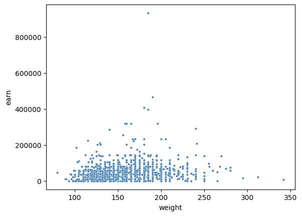

```python
sns.scatterplot(data = train,
                x = 'weight',
                y = 'earn',
                color='steelblue',
                s=10)
plt.show()
```

### Fit Model

```python
reg = ols('earn~weight', data = train)
model2 = reg.fit()
model2.params
```

```
Intercept    11764.090483
weight         238.823119
dtype: float64
```

### Predict

```python
r_squared2 = model2.rsquared
r_squared2
```

```
np.float64(0.023262707432168517)
```

```python
pred = model2.predict()
rmse2 = np.sqrt(np.mean(np.square(pred - train.earn)))
rmse2
```

```
np.float64(53605.915916639606)
```

### Inference

Next, we examine the model summary to see if weight exerts a statistically significant effect on earn.

```python
print(model2.summary())
```

```
                            OLS Regression Results
==============================================================================
Dep. Variable:                   earn   R-squared:                       0.023
Model:                            OLS   Adj. R-squared:                  0.022
Method:                 Least Squares   F-statistic:                     29.72
Date:                Thu, 25 Sep 2025   Prob (F-statistic):           6.00e-08
Time:                        18:46:17   Log-Likelihood:                -15385.
No. Observations:                1250   AIC:                         3.077e+04
Df Residuals:                    1248   BIC:                         3.079e+04
Df Model:                           1
Covariance Type:            nonrobust
==============================================================================
                 coef    std err          t      P>|t|      [0.025      0.975]
------------------------------------------------------------------------------
Intercept   1.176e+04   7020.653      1.676      0.094   -2009.494    2.55e+04
weight       238.8231     43.805      5.452      0.000     152.883     324.764
==============================================================================
Omnibus:                     1424.660   Durbin-Watson:                   2.001
Prob(Omnibus):                  0.000   Jarque-Bera (JB):           222874.979
Skew:                           5.435   Prob(JB):                         0.00
Kurtosis:                      67.506   Cond. No.                         742.
==============================================================================

Notes:
[1] Standard Errors assume that the covariance matrix of the errors is correctly specified.
```

## 3. Simple Regression, Categorical Variable: gender

Let us examine the relationship between gender and earn. Since gender is categorical, we will examine the relationship using a bar chart instead of a scatterplot.

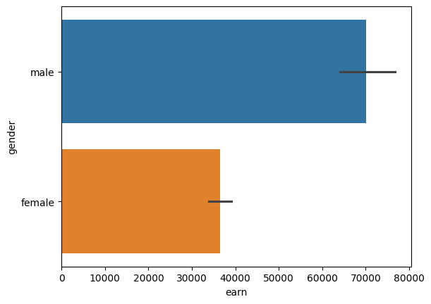

```python
sns.barplot(data = train,
                y = 'gender',
                x = 'earn',
                hue = 'gender',orient = 'h')
plt.show()
```

### Fit

Next, estimate a regression using gender as predictor of earn. Since gender is a categorical variable with two levels, ols() will automatically dummy code the variable setting the first level as reference.

```python
reg = ols('earn ~ gender', data = train)
model3 = reg.fit()
```

### Predict

```python
r_squared3 = model3.rsquared
r_squared3
```

```
np.float64(0.09079695073221739)
```

```python
pred = model3.predict()
rmse3 = np.sqrt(np.mean(np.square(pred - train.earn)))
rmse3
```

```
np.float64(51719.4952450114)
```

### Inference

Next, let us see if the effect of gender on earn is statistically significant.

```python
print(model3.summary())
```

```
                            OLS Regression Results
==============================================================================
Dep. Variable:                   earn   R-squared:                       0.091
Model:                            OLS   Adj. R-squared:                  0.090
Method:                 Least Squares   F-statistic:                     124.6
Date:                Thu, 25 Sep 2025   Prob (F-statistic):           1.19e-27
Time:                        18:46:17   Log-Likelihood:                -15341.
No. Observations:                1250   AIC:                         3.069e+04
Df Residuals:                    1248   BIC:                         3.070e+04
Df Model:                           1
Covariance Type:            nonrobust
==================================================================================
                     coef    std err          t      P>|t|      [0.025      0.975]
----------------------------------------------------------------------------------
Intercept       3.643e+04   1854.527     19.642      0.000    3.28e+04    4.01e+04
gender[T.male]  3.373e+04   3021.188     11.164      0.000    2.78e+04    3.97e+04
==============================================================================
Omnibus:                     1453.941   Durbin-Watson:                   1.977
Prob(Omnibus):                  0.000   Jarque-Bera (JB):           255035.108
Skew:                           5.596   Prob(JB):                         0.00
Kurtosis:                      72.075   Cond. No.                         2.43
==============================================================================

Notes:
[1] Standard Errors assume that the covariance matrix of the errors is correctly specified.
```

Since gender has been dummy coded with female as the reference level, the regression coefficient reflects the difference in earn between those who are male and those who are female.

## 4. Simple Regression, Categorical Predictor: ethnicity

Let us examine the relationship between ethnicity and earn using a box plot.

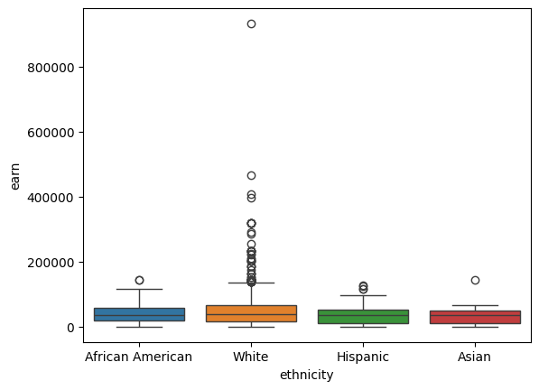

```python
sns.boxplot(data = train,
                x= 'ethnicity',
                y = 'earn',
                hue = 'ethnicity')
plt.show()
```

### Fit

Estimate a regression using ethnicity as predictor of earn. Since ethnicity is a categorical variable, ols() will automatically create k-1 dummy variables where k is the number of levels of ethnicity. The first level based on alphabetical order will serve as reference level.

```python
reg = ols('earn ~ ethnicity', data = train)
model4 = reg.fit()
```

### Predict

```python
model4.pvalues
```

```
Intercept                4.839267e-16
ethnicity[T.Asian]       7.624861e-01
ethnicity[T.Hispanic]    6.209750e-01
ethnicity[T.White]       3.646812e-02
dtype: float64
```

```python
r_squared4 = model4.rsquared
r_squared4
```

```
np.float64(0.008061431917691153)
```

```python
pred = model4.predict()
rmse4 = np.sqrt(np.mean(np.square(pred - train.earn)))
rmse4
```

```
np.float64(54021.448417021566)
```

### Inference

```python
print(model4.summary())
```

```
                            OLS Regression Results
==============================================================================
Dep. Variable:                   earn   R-squared:                       0.008
Model:                            OLS   Adj. R-squared:                  0.006
Method:                 Least Squares   F-statistic:                     3.375
Date:                Thu, 25 Sep 2025   Prob (F-statistic):             0.0178
Time:                        18:46:18   Log-Likelihood:                -15395.
No. Observations:                1250   AIC:                         3.080e+04
Df Residuals:                    1246   BIC:                         3.082e+04
Df Model:                           3
Covariance Type:            nonrobust
=========================================================================================
                            coef    std err          t      P>|t|      [0.025      0.975]
-----------------------------------------------------------------------------------------
Intercept              4.046e+04   4918.917      8.226      0.000    3.08e+04    5.01e+04
ethnicity[T.Asian]    -3948.0169   1.31e+04     -0.302      0.762   -2.96e+04    2.17e+04
ethnicity[T.Hispanic] -3885.9413   7856.855     -0.495      0.621   -1.93e+04    1.15e+04
ethnicity[T.White]     1.089e+04   5199.558      2.094      0.036     686.641    2.11e+04
==============================================================================
Omnibus:                     1421.294   Durbin-Watson:                   1.988
Prob(Omnibus):                  0.000   Jarque-Bera (JB):           219279.940
Skew:                           5.418   Prob(JB):                         0.00
Kurtosis:                      66.975   Cond. No.                         11.8
==============================================================================

Notes:
[1] Standard Errors assume that the covariance matrix of the errors is correctly specified.
```

## 5. Multiple Regression: weight, gender, weight*gender

We are now going to use multiple predictors, therefore the model used is a multiple regression. We will examine the effects of gender and weight, both of which were found to be statistically significant. In addition, we will examine the joint effect or interaction of weight and gender.

### Fit

```python
reg = ols('earn ~ weight*gender', data = train)
model5 = reg.fit()
```

### Inference

```python
print(model5.summary())
```

```
                            OLS Regression Results
==============================================================================
Dep. Variable:                   earn   R-squared:                       0.098
Model:                            OLS   Adj. R-squared:                  0.095
Method:                 Least Squares   F-statistic:                     44.88
Date:                Thu, 25 Sep 2025   Prob (F-statistic):           1.53e-27
Time:                        18:46:18   Log-Likelihood:                -15336.
No. Observations:                1250   AIC:                         3.068e+04
Df Residuals:                    1246   BIC:                         3.070e+04
Df Model:                           3
Covariance Type:            nonrobust
=========================================================================================
                            coef    std err          t      P>|t|      [0.025      0.975]
-----------------------------------------------------------------------------------------
Intercept              4.751e+04   8845.920      5.371      0.000    3.02e+04    6.49e+04
gender[T.male]        -1.478e+04   1.63e+04     -0.904      0.366   -4.68e+04    1.73e+04
weight                  -76.8149     59.933     -1.282      0.200    -194.395      40.766
weight:gender[T.male]   288.7331     97.295      2.968      0.003      97.853     479.613
==============================================================================
Omnibus:                     1457.188   Durbin-Watson:                   1.983
Prob(Omnibus):                  0.000   Jarque-Bera (JB):           258131.249
Skew:                           5.616   Prob(JB):                         0.00
Kurtosis:                      72.498   Cond. No.                     2.13e+03
==============================================================================

Notes:
[1] Standard Errors assume that the covariance matrix of the errors is correctly specified.
[2] The condition number is large, 2.13e+03. This might indicate that there are
strong multicollinearity or other numerical problems.
```

Model summary indicates a statistically significant interaction effect of weight and gender. To gain more insight on the nature and meaning of this interaction, we will plot the results.

Direction of interaction shows the effect of weight on earn has very different effects for males and females. For males, an increase in weight is tied to an increase in earn, while for females the opposite is true.

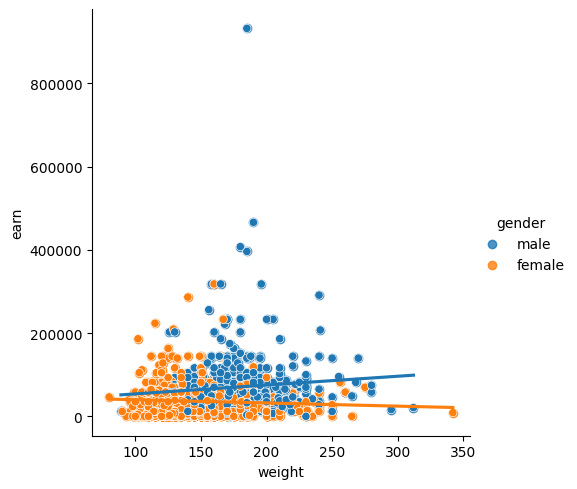

```python
sns.lmplot(data = train,
           x = 'weight',
           y = 'earn',
           hue = 'gender',
           ci = None)
sns.scatterplot(data = train,
           x = 'weight',
           y = 'earn',
           hue = 'gender',
                legend=False)
plt.show()
```

### Predict

```python
r_squared5 = model5.rsquared
r_squared5
```

```
np.float64(0.0975239948720068)
```

```python
pred = model5.predict()
rmse5 = np.sqrt(np.mean(np.square(pred - train.earn)))
rmse5
```

```
np.float64(51527.807992638496)
```

## 6. Multiple Regression: All predictors

Generally speaking, adding more meaningful predictors will improve the quality of predictions. So, we are going to include all the predictors in our next model. Since this model uses multiple predictors, it is called multiple regression.

### Fit

```python
reg = ols('earn ~ age + gender + height + weight + ethnicity + education + walk + exercise + smokenow + tense', data = train)
model6 = reg.fit()
```

### Predict

```python
r_squared6 = model6.rsquared
r_squared6
```

```
np.float64(0.20028177721365903)
```

```python
pred = model6.predict()
rmse6 = np.sqrt(np.mean(np.square(pred - train.earn)))
rmse6
```

```
np.float64(48505.650370861804)
```

### Inference

The model summary provides us information to explain the predictions. You will notice the inferences from multiple regression are not the same as for simple regression.

The coefficients for significant variables can be interpreted in a manner similar to simple regression with the caveat of ceteris paribus. For instance, one year of education corresponds to an increase in earn of $6471.9786 while holding all other variables constant.

```python
print(model6.summary())
```

```
                            OLS Regression Results
==============================================================================
Dep. Variable:                   earn   R-squared:                       0.200
Model:                            OLS   Adj. R-squared:                  0.193
Method:                 Least Squares   F-statistic:                     25.82
Date:                Thu, 25 Sep 2025   Prob (F-statistic):           2.38e-52
Time:                        18:46:18   Log-Likelihood:                -15260.
No. Observations:                1250   AIC:                         3.055e+04
Df Residuals:                    1237   BIC:                         3.061e+04
Df Model:                          12
Covariance Type:            nonrobust
=========================================================================================
                            coef    std err          t      P>|t|      [0.025      0.975]
-----------------------------------------------------------------------------------------
Intercept               -1.1e+05   3.56e+04     -3.093      0.002    -1.8e+05   -4.02e+04
gender[T.male]         3.086e+04   4089.922      7.546      0.000    2.28e+04    3.89e+04
ethnicity[T.Asian]    -5419.4781   1.19e+04     -0.456      0.648   -2.87e+04    1.79e+04
ethnicity[T.Hispanic] -1054.8210   7189.010     -0.147      0.883   -1.52e+04     1.3e+04
ethnicity[T.White]     5336.7189   4738.480      1.126      0.260   -3959.627    1.46e+04
age                     445.7606     90.864      4.906      0.000     267.495     624.026
height                  562.1321    555.369      1.012      0.312    -527.436    1651.701
weight                  -13.8389     49.423     -0.280      0.780    -110.800      83.122
education              6471.9786    557.408     11.611      0.000    5378.409    7565.548
walk                   -113.6744    542.884     -0.209      0.834   -1178.749     951.400
exercise                298.6003    671.630      0.445      0.657   -1019.060    1616.260
smokenow                638.9624   3263.319      0.196      0.845   -5763.289    7041.214
tense                  1221.4603    699.545      1.746      0.081    -150.965    2593.886
==============================================================================
Omnibus:                     1563.813   Durbin-Watson:                   1.990
Prob(Omnibus):                  0.000   Jarque-Bera (JB):           411216.690
Skew:                           6.246   Prob(JB):                         0.00
Kurtosis:                      90.973   Cond. No.                     4.64e+03
==============================================================================

Notes:
[1] Standard Errors assume that the covariance matrix of the errors is correctly specified.
[2] The condition number is large, 4.64e+03. This might indicate that there are
strong multicollinearity or other numerical problems.
```

## Predict Out of Sample

```python
pred = model1.predict(test)
test_rmse1 = np.sqrt(np.mean(np.square(pred - test.earn)))

pred = model2.predict(test)
test_rmse2 = np.sqrt(np.mean(np.square(pred - test.earn)))

pred = model3.predict(test)
test_rmse3 = np.sqrt(np.mean(np.square(pred - test.earn)))

pred = model4.predict(test)
test_rmse4 = np.sqrt(np.mean(np.square(pred - test.earn)))

pred = model5.predict(test)
test_rmse5 = np.sqrt(np.mean(np.square(pred - test.earn)))

pred = model6.predict(test)
test_rmse6 = np.sqrt(np.mean(np.square(pred - test.earn)))
```

```python
pd.DataFrame({'model':['model1','model2','model3','model4','model5','model6'],
              'train_rmse': [rmse1, rmse2,rmse3,rmse4,rmse5,rmse6],
              'test_rmse': [test_rmse1, test_rmse2, test_rmse3, test_rmse4, test_rmse5, test_rmse6]}).set_index('model')
```

| model | train_rmse | test_rmse |
| --- | --- | --- |
| model1 | 54141.254328 | 48906.822669 |
| model2 | 53605.915917 | 48226.553145 |
| model3 | 51719.495245 | 46722.468030 |
| model4 | 54021.448417 | 49175.659163 |
| model5 | 51527.807993 | 46278.032558 |
| model6 | 48505.650371 | 43572.921118 |

## Summary

In this note, we examined implementation of Linear Regression for prediction and inference with

- one numeric feature
- one categorical feature
- an interaction between two features
- multiple features

All models were estimated using functions from StatsModels to emphasize statistical details.

This file was generated using Python 3.13.5 on Windows 10 with the following libraries: matplotlib 3.10.3, numpy 2.3.1, pandas 2.3.0, scipy 1.16.0, seaborn 0.13.2, statsmodels 0.14.5